# VECMX Models - Forecasts

Mihaela Solcan

19 May 2017

Load the packages

```r
suppressPackageStartupMessages({
library(vars)
library(knitr)
library(pander)
library(urca)
library(tsDyn)
library(forecast)
library(xtable)
set.seed(12345)
library(VARsignR)
})
```

### Data

The data contain two sets of variables:

- **endogenous variables**: oil market fundamentals: demand, supply, Brent price, inventories;
- **exogenous variables**: economic indicators: recession, OPEC meetings, expectations of business cycles measured by interest rate spreads (the yield curve), interest rates, industrial production indicators.

The following regional models have been estimated:

```r
pandoc.table(vecm_data, justify = 'left',caption = 'Variables used in VECMX models',
             split.table = Inf, style="multiline")
```

```
-------------------------------------------------------------------------------------------
Models                        Endogenous                     Exogenous
----------------------------- ------------------------------ ------------------------------
World                         Global demand for liquids      Recession

                              Global production of liquids   OPEC meeting

                              Brent spot price               Seasonality

                              Global inventory changes       Global Industrial Production

                                                             Interest rate spread (expected
                                                             business cycle)

OPEC/Non-OPEC - World Demand  Global demand for liquids

                              OPEC production of liquids

                              Non-OPEC production of liquids

                              Brent spot price

                              Global inventory changes



OEPC/Non-OPEC - OECD/Non-OECD OECD demand for liquids
Demand

                              Non-OECD demand for liquids

                              OPEC production of liquids

                              Non-OPEC production of liquids

                              Brent spot price

                              Global inventory changes
-------------------------------------------------------------------------------------------

Table: Variables used in VECMX models
```

```r
setwd("C:/Users/mfp43003/Desktop/EAA/VECM")
ihs_predictions <- ts(xlsx::read.xlsx("VAR Data.xlsx", sheetName = "Hindsight forecasts", colIndex = 2:20,
                           startRow = 1, header=T), start=c(2016,11),freq=12)
dt <- ts(xlsx::read.xlsx("VAR Data.xlsx", sheetName = "data", colIndex = 2:59,
                             startRow = 1, header=T), start=c(2001,1),freq=12)
exog <- c("Recession", "OPEC_Meeting", "IP_WOR_M_LOG","RMSPREAD_WOR_M_FGI","Jan", "Feb", "Mar", "Apr","May",
          "Jun", "Jul", "Aug", "Sep","Oct","Nov")
X_forc <- window(ihs_predictions[,exog], start=c(2016,11), end=c(2017,4))
X <- window(dt[,exog], end=c(2016,10))
endog_wor <- c("D_WOR_LIQUIDS","P_WOR_LIQUIDS","POILBNT_WOR_M_FGI","INVCHANGE_WOR_LIQUIDS")
Y_wor <- window(dt[,endog_wor], end=c(2016,10))
Y_wor_log<- cbind(D_WOR_LIQUIDS=log(Y_wor[, "D_WOR_LIQUIDS"]),
                  P_WOR_LIQUIDS=log(Y_wor[, "P_WOR_LIQUIDS"]),
                  POILBNT_WOR_M_FGI = log(Y_wor[,"POILBNT_WOR_M_FGI"]),
                  INVCHANGE_WOR_LIQUIDS=Y_wor[,"INVCHANGE_WOR_LIQUIDS"])
endog_oecd <- c("D_OECD_LIQUIDS","D_NONOECD_LIQUIDS","P_NONOPEC_LIQUIDS","P_OPEC_LIQUIDS","POILBNT_WOR_M_FGI","INVCHANGE_WOR_LIQUIDS")
Y_oecd<- window(dt[,endog_oecd], end=c(2016,10))
Y_oecd_log<-cbind(D_OECD_LIQUIDS=log(Y_oecd[,"D_OECD_LIQUIDS"]), D_NONOECD_LIQUIDS=log(Y_oecd[,"D_NONOECD_LIQUIDS"]),
                  P_NONOPEC_LIQUIDS=log(Y_oecd[,"P_NONOPEC_LIQUIDS"]),
                  P_OPEC_LIQUIDS=log(Y_oecd[,"P_OPEC_LIQUIDS"]), POILBNT_WOR_M_FGI=log(Y_oecd[,"POILBNT_WOR_M_FGI"]),
                  INVCHANGE_WOR_LIQUIDS=Y_oecd[,"INVCHANGE_WOR_LIQUIDS"])
endog_opec <- c("D_WOR_LIQUIDS","P_NONOPEC_LIQUIDS","P_OPEC_LIQUIDS","POILBNT_WOR_M_FGI","INVCHANGE_WOR_LIQUIDS")
Y_opec <- window(dt[,endog_opec], end=c(2016,10))
Y_opec_log<-cbind(D_WOR_LIQUIDS=log(Y_opec[,"D_WOR_LIQUIDS"]),P_NONOPEC_LIQUIDS=log(Y_opec[,"P_NONOPEC_LIQUIDS"]),
                  P_OPEC_LIQUIDS=log(Y_opec[,"P_OPEC_LIQUIDS"]), POILBNT_WOR_M_FGI=log(Y_opec[,"POILBNT_WOR_M_FGI"]),
                  INVCHANGE_WOR_LIQUIDS=Y_opec[,"INVCHANGE_WOR_LIQUIDS"])
```

#### Plots of the data

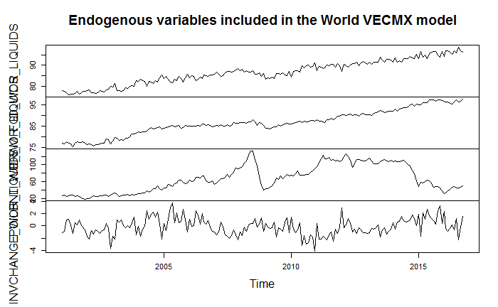

```r
plot(Y_wor, ylab="",main="Endogenous variables included in the World VECMX model")
```

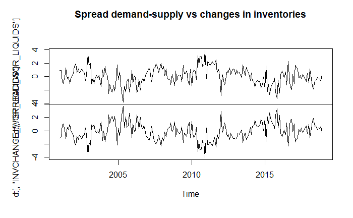

```r
plot(cbind(dt[,"SPREAD_WOR_LIQUIDS"], dt[,"INVCHANGE_WOR_LIQUIDS"]), col=1:2, main="Spread demand-supply vs changes in inventories", ylab="")
```

```r
correlation<-cor(dt[,"SPREAD_WOR_LIQUIDS"], dt[,"INVCHANGE_WOR_LIQUIDS"])
print(correlation)
```

```
[1] -0.9929912
```

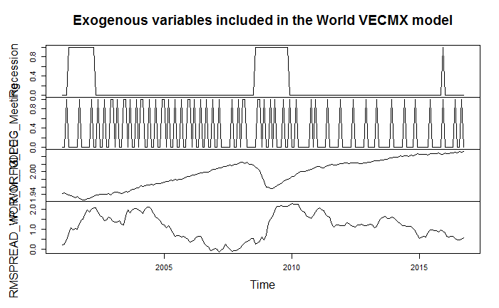

```r
plot(X[,1:4], main="Exogenous variables included in the World VECMX model")
```

### VECMX Model

The VECMX in math notation is given by:

$Y_{t} = c_{0} + c_{1}t + \Pi Y_{t-1} + B_{1} \Delta Y_{t-1} + \gamma_{1} OPEC Meeting_{t} + \gamma_{2} GlobalIP_{t} + \gamma_{3} GlobalSPREAD_{t} + \gamma_{4} Recession_{t} + \sum_{m} s_{m} Season +\epsilon_{t}$,

$\epsilon_{t} \sim N(0, \Sigma)$

Where $Y_{t}$ represents the vector of endogenous variables:

$$Y_{t} = \begin{bmatrix}
global \ demand \ for \ liquids \\
global \ supply \ of \ liquids \\
global \ brent \ prices \\
global \ liquids \ inventories
\end{bmatrix}$$

The matrix $\Pi$ represents the long-run multiplier matrix of the system and is derived from the reduced-form of the VAR model in levels:

$Y_{t} = c_{0} + c_{1}t + A_{1}Y_{t-1} + A_{2}Y_{t-2} + \epsilon_{t}$

then,

$\Pi = (A_{1} + A_{2} - I_{2})$

### VAR models in error correction form

1. Check the endogenous variables are I(1):

```r
lagOrder = trunc((nrow(Y_wor)-1)^(1/3))
Test <- apply(Y_wor,2,adf.test, alternative="stationary", k=lagOrder)
print(Test)
```

```
$D_WOR_LIQUIDS

    Augmented Dickey-Fuller Test

data:  newX[, i]
Dickey-Fuller = -2.7404, Lag order = 5, p-value = 0.2664
alternative hypothesis: stationary


$P_WOR_LIQUIDS

    Augmented Dickey-Fuller Test

data:  newX[, i]
Dickey-Fuller = -2.1133, Lag order = 5, p-value = 0.5288
alternative hypothesis: stationary


$POILBNT_WOR_M_FGI

    Augmented Dickey-Fuller Test

data:  newX[, i]
Dickey-Fuller = -1.7909, Lag order = 5, p-value = 0.6637
alternative hypothesis: stationary


$INVCHANGE_WOR_LIQUIDS

    Augmented Dickey-Fuller Test

data:  newX[, i]
Dickey-Fuller = -2.7122, Lag order = 5, p-value = 0.2782
alternative hypothesis: stationary
```

2. Test for the number of cointegration relations between the endogenous variables with Johansen’ procedure. The procedure consists of two steps:
- test for the rank of matrix $\Pi$. The rank represents the number of cointegrating relationships between the endogenous variables. This represents **the number of linear combinations of the non-stationary endogenous variables that are stationary.**
- if the matrix $\Pi$ is of reduced rank, or if there is at least one cointegrating relation between the endogenous variables, $\Pi$ can be decomposed into two $(n \times r)$ matrices:

  $\Pi = \alpha \beta'$ such that $\beta'Y_{t} \sim I(0)$, where

  $\alpha$ contains the loading parameters of the speed of adjustment of the variables to the long-run equilibrium.

  $\beta$ represents the cointegration vector, or the long-run relationship between the oil market fundamentals.

```r
coint_opec <- ca.jo(Y_opec, type = "eigen", ecdet = "trend", K = 2, spec = "longrun", season=12)
coint_oecd <- ca.jo(Y_oecd, type = "eigen", ecdet = "trend", K = 2, spec = "longrun", season=12)
coint_world <- ca.jo(Y_wor, type = "eigen", ecdet = "trend", K = 2, spec = "longrun", season=12)
coint_world
```

```
#####################################################
# Johansen-Procedure Unit Root / Cointegration Test #
#####################################################

The value of the test statistic is: 2.408 7.1793 35.6743 65.4189
```

```r
coint_world@cval
```

```
         10pct  5pct  1pct
r <= 3 | 10.49 12.25 16.26
r <= 2 | 16.85 18.96 23.65
r <= 1 | 23.11 25.54 30.34
r = 0  | 29.12 31.46 36.65
```

3. Estimation and forecasts: the global model

```r
vecm_world <- VECM(Y_wor, lag=2, r = 1, include = "both", beta = NULL, estim = "ML", exogen = X)
forc.world <- predict(vecm_world, n.ahead = nrow(X_forc), exoPred =X_forc)
vecm_world_log <- VECM(Y_wor_log, lag=2, r = 1, include = "both", beta = NULL, estim = "ML", exogen = X)
forc.world.log <- predict(vecm_world_log, n.ahead = nrow(X_forc), exoPred =X_forc)
#OPEC
vecm_opec<- VECM(Y_opec, lag=2, r = 1, include = "both", beta = NULL, estim = "ML", exogen = X)
forc.opec <- predict(vecm_opec, n.ahead = nrow(X_forc), exoPred =X_forc)
vecm_opec_log <- VECM(Y_opec_log, lag=2, r = 1, include = "both", beta = NULL, estim = "ML", exogen = X)
forc.opec.log <- predict(vecm_opec_log, n.ahead = nrow(X_forc), exoPred =X_forc)
#OECD
vecm_oecd <- VECM(Y_oecd, lag=2, r = 1, include = "both", beta = NULL, estim = "ML", exogen = X)
forc.oecd <- predict(vecm_oecd, n.ahead = nrow(X_forc), exoPred =X_forc)
vecm_oecd_log <- VECM(Y_oecd_log, lag=2, r = 1, include = "both", beta = NULL, estim = "ML", exogen = X)
forc.oecd.log <- predict(vecm_oecd_log, n.ahead = nrow(X_forc), exoPred =X_forc)
```

Coefficient estimates:

- the long-run relationship between the oil market fundamentals is given by the cointegrating vector, normalized with respect to the first variable in the set of endogenous variables:

```r
vecm_world$model.specific$coint
```

```
                                 r1
D_WOR_LIQUIDS          1.0000000000
P_WOR_LIQUIDS         -0.9996651170
POILBNT_WOR_M_FGI     -0.0005359607
INVCHANGE_WOR_LIQUIDS  1.0090756272
```

This represent the linear combination of the I(1) variables that is stationary. Thus, the long-run relationship is:

$Demand = 0.99*Supply + 0.00053*Price - 1.00907*Inventories$

In order to see how Brent prices are affected in the short run by an increase in oil supply or demand, we can analyze the second lagged coefficients of demand and supply of the equation where d.Pol is the dependent variable: not surprisingly, increases in demand have a positive impact while increases in supply have a negative effect on prices.

I used the second lag to allow some time to prices to adjust to these changes.

```r
vecm_world$coefficients[3,8:9]
```

```
D_WOR_LIQUIDS -2 P_WOR_LIQUIDS -2
       0.8040376       -0.5599087
```

The rest of the coefficients are shown below:

```r
vecm_world$coefficients
```

```
                                      ECT  Intercept        Trend D_WOR_LIQUIDS -1 P_WOR_LIQUIDS -1
Equation D_WOR_LIQUIDS         -0.3951972   4.561860  0.001115229       -0.2734840      -0.36572547
Equation P_WOR_LIQUIDS          0.1124413  -6.870797 -0.001499852        0.1258806      -0.36655732
Equation POILBNT_WOR_M_FGI     -0.5708726  74.441912  0.011156464        1.1184652      -0.68912410
Equation INVCHANGE_WOR_LIQUIDS -0.2585386 -15.251462 -0.003241647        0.4610005      -0.06053092
                               POILBNT_WOR_M_FGI -1 INVCHANGE_WOR_LIQUIDS -1 D_WOR_LIQUIDS -2
Equation D_WOR_LIQUIDS                  -0.01820176               0.29419795       -0.3562199
Equation P_WOR_LIQUIDS                   0.01728802               0.14416703       -0.1248060
Equation POILBNT_WOR_M_FGI               0.31280914               0.86722686        0.8040376
Equation INVCHANGE_WOR_LIQUIDS           0.03566512              -0.09158022        0.2402605
                               P_WOR_LIQUIDS -2 POILBNT_WOR_M_FGI -2 INVCHANGE_WOR_LIQUIDS -2  Recession
Equation D_WOR_LIQUIDS              -0.02667437          0.012914699              -0.04967332 -0.4679384
Equation P_WOR_LIQUIDS              -0.13818628         -0.002783123              -0.08965045 -0.2894997
Equation POILBNT_WOR_M_FGI          -0.55990865          0.010460849               0.48490743 -2.6365022
Equation INVCHANGE_WOR_LIQUIDS      -0.09951798         -0.018377919              -0.04113271  0.2097982
                               OPEC_Meeting IP_WOR_M_LOG RMSPREAD_WOR_M_FGI        Jan         Feb        Mar
Equation D_WOR_LIQUIDS           0.11717320    -1.844647         0.14428124 -2.0032498 -0.04931667 -1.7070118
Equation P_WOR_LIQUIDS           0.21497875     3.247174         0.19504290  0.4045084  0.43017622  0.1431582
Equation POILBNT_WOR_M_FGI      -0.57967376   -37.822251         0.02498110  0.7751468  2.85251908  3.0163739
Equation INVCHANGE_WOR_LIQUIDS   0.06811881     6.927441         0.09181136  2.4791227  0.57109874  1.9231446
                                      Apr        May        Jun        Jul        Aug        Sep        Oct
Equation D_WOR_LIQUIDS         -1.4420716 -1.9831547 -0.1927014 -0.2989166 -0.2318333 -1.0711079 -1.3297495
Equation P_WOR_LIQUIDS          0.4377184  0.3679598  0.3257198  1.0330014  0.4174754  0.1991153  0.9781249
Equation POILBNT_WOR_M_FGI      1.0640504  0.7926920  1.3166276  1.0183468 -0.9398230 -0.7085375 -0.6813214
Equation INVCHANGE_WOR_LIQUIDS  2.0508319  2.4635107  0.6144637  1.4857222  0.7892061  1.4279337  2.4497613
                                      Nov
Equation D_WOR_LIQUIDS         -0.7959079
Equation P_WOR_LIQUIDS          0.6237869
Equation POILBNT_WOR_M_FGI     -0.9443216
Equation INVCHANGE_WOR_LIQUIDS  1.4728198
```

4. Compare forecasts to actual data:

```r
brent_world <- ts(cbind(window(dt[,"POILBNT_WOR_M_FGI"], start=c(2016,11), end=c(2017,4)),
                        forc.world[,"POILBNT_WOR_M_FGI"]) ,start=c(2016,11), freq=12)
demand_world <- ts(cbind(window(dt[,"D_WOR_LIQUIDS"], start=c(2016,11), end=c(2017,4)), forc.world[,"D_WOR_LIQUIDS"]), start=c(2016,11), freq=12)
production_world <- ts(cbind(window(dt[,"P_WOR_LIQUIDS"], start=c(2016,11), end=c(2017,4)), forc.world[,"P_WOR_LIQUIDS"]), start=c(2016,11), freq=12)
par(mfrow=c(3,1))
plot(brent_world, ylim=range(39,60),plot.type=c("single"), col=1:2)
plot(demand_world, plot.type=c("single"), col=1:2)
```

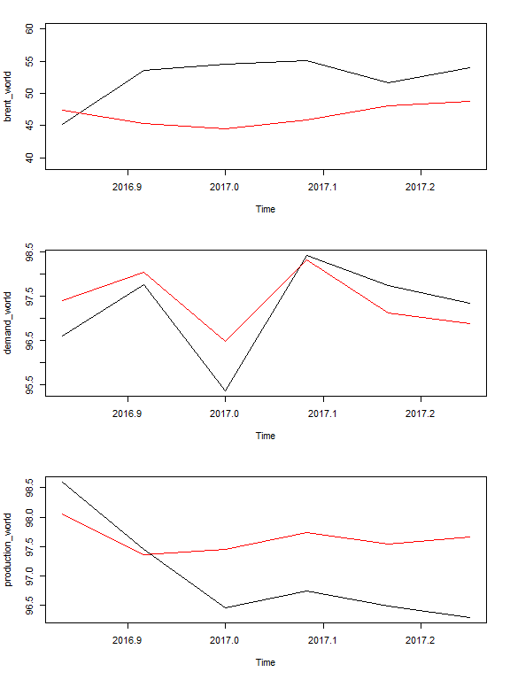

```r
plot(production_world, plot.type=c("single"), col=1:2)
```

### Simulations with impulse-response functions

Test the impact of a positive shock to oil supply - measured as a positive one standard deviation of the oil supply series.

Identify the shock by imposing sign restrictions on the responses of several variables.

```
+-----------------+---------------+---------------+--------------+-----------------------+
|    Variables    | Global demand | Global supply | Brent prices | Change in inventories |
+-----------------+---------------+---------------+--------------+-----------------------+
|      Shock      |     none      |       +       |     none     |           +           |
+-----------------+---------------+---------------+--------------+-----------------------+

Table: Sign restrictions for the global market
```

Plot the responses of the system to a positive shock to global oil supply:

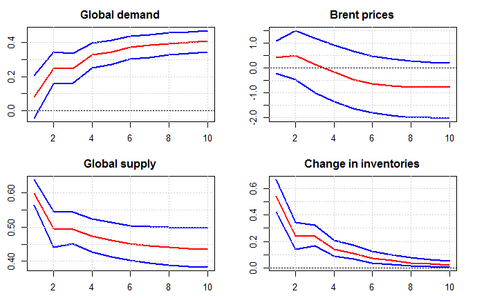

```r
irfplot(irfdraws=irfs, type="median", labels=vl, save=FALSE, bands=c(0.16, 0.84),
        grid=TRUE, bw=FALSE)
```

### Additional models

Plots of out-of-sample forecasts:

#### WORLD

```r
brent_world <- ts(cbind(window(dt[,"POILBNT_WOR_M_FGI"], start=c(2016,11), end=c(2017,4)),
                        forc.world[,"POILBNT_WOR_M_FGI"]) ,start=c(2016,11), freq=12)
brent_world_log <- ts(cbind(window(dt[,"POILBNT_WOR_M_FGI"], start=c(2016,11), end=c(2017,4)),
                        exp(forc.world.log[,"POILBNT_WOR_M_FGI"])) ,start=c(2016,11), freq=12)


demand_world <- ts(cbind(window(dt[,"D_WOR_LIQUIDS"], start=c(2016,11), end=c(2017,4)), forc.world[,"D_WOR_LIQUIDS"]),
                   start=c(2016,11), freq=12)
demand_world_log <- ts(cbind(window(dt[,"D_WOR_LIQUIDS"], start=c(2016,11), end=c(2017,4)), exp(forc.world.log[,"D_WOR_LIQUIDS"])),
                   start=c(2016,11), freq=12)



production_world <- ts(cbind(window(dt[,"P_WOR_LIQUIDS"], start=c(2016,11), end=c(2017,4)), forc.world[,"P_WOR_LIQUIDS"]),
                       start=c(2016,11), freq=12)
production_world_log <- ts(cbind(window(dt[,"P_WOR_LIQUIDS"], start=c(2016,11), end=c(2017,4)), exp(forc.world.log[,"P_WOR_LIQUIDS"])),
                       start=c(2016,11), freq=12)
```

```r
par(mfrow=c(3,1))
plot(brent_world, plot.type=c("single"), col=1:2)
plot(demand_world, plot.type=c("single"), col=1:2)
```

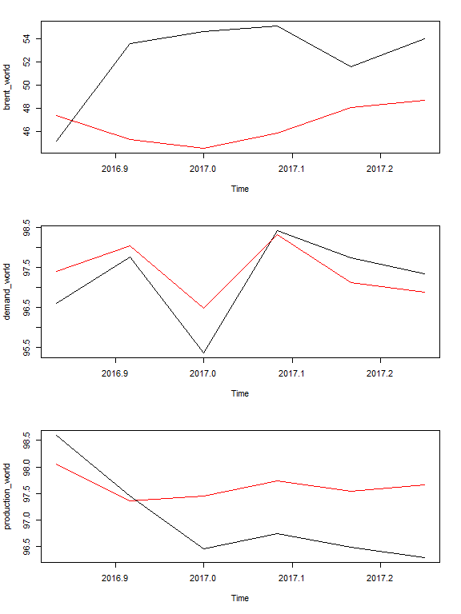

```r
plot(production_world, plot.type=c("single"), col=1:2)
```

```r
par(mfrow=c(3,1))
plot(brent_world_log, plot.type=c("single"), col=1:2)
plot(demand_world_log, plot.type=c("single"), col=1:2)
plot(production_world_log, plot.type=c("single"), col=1:2)
```

[output not shown]

#### OPEC

```r
brent_opec <- ts(cbind(window(dt[,"POILBNT_WOR_M_FGI"], start=c(2016,11), end=c(2017,4)), forc.opec[,"POILBNT_WOR_M_FGI"]),
                 start=c(2016,11), freq=12)
brent_opec_log <- ts(cbind(window(dt[,"POILBNT_WOR_M_FGI"], start=c(2016,11), end=c(2017,4)), exp(forc.opec.log[,"POILBNT_WOR_M_FGI"])),
                 start=c(2016,11), freq=12)


demand_opec <- ts(cbind(window(dt[,"D_WOR_LIQUIDS"], start=c(2016,11), end=c(2017,4)), forc.opec[,"D_WOR_LIQUIDS"]),
                  start=c(2016,11), freq=12)
demand_opec_log <- ts(cbind(window(dt[,"D_WOR_LIQUIDS"], start=c(2016,11), end=c(2017,4)), exp(forc.opec.log[,"D_WOR_LIQUIDS"])),
                  start=c(2016,11), freq=12)


production_opec <- ts(cbind(window(dt[,"P_OPEC_LIQUIDS"], start=c(2016,11), end=c(2017,4)), forc.opec[,"P_OPEC_LIQUIDS"]),
                      start=c(2016,11), freq=12)
production_opec_log <- ts(cbind(window(dt[,"P_OPEC_LIQUIDS"], start=c(2016,11), end=c(2017,4)), exp(forc.opec.log[,"P_OPEC_LIQUIDS"])),
                      start=c(2016,11), freq=12)
```

```r
par(mfrow=c(3,1))
plot(brent_opec, plot.type=c("single"), col=1:2)
plot(demand_opec, plot.type=c("single"), col=1:2)
```

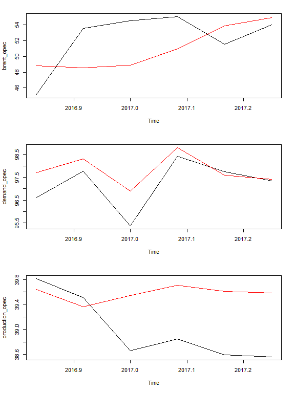

```r
plot(production_opec, plot.type=c("single"), col=1:2)
```

```r
par(mfrow=c(3,1))
plot(brent_opec_log, plot.type=c("single"), col=1:2)
plot(demand_opec_log, plot.type=c("single"), col=1:2)
```

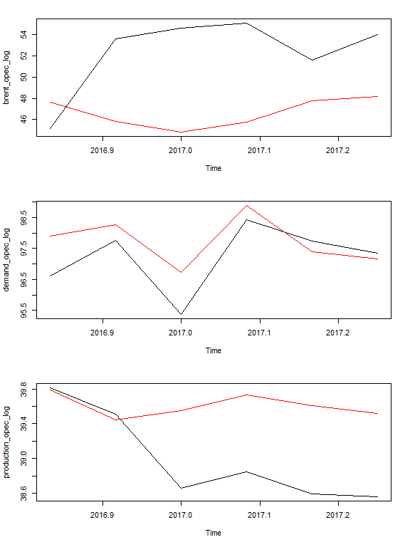

```r
plot(production_opec_log, plot.type=c("single"), col=1:2)
```

#### OECD

```r
brent_oecd <- ts(cbind(window(dt[,"POILBNT_WOR_M_FGI"], start=c(2016,11), end=c(2017,4)), forc.oecd[,"POILBNT_WOR_M_FGI"]),
                 start=c(2016,11), freq=12)
brent_oecd_log <- ts(cbind(window(dt[,"POILBNT_WOR_M_FGI"], start=c(2016,11), end=c(2017,4)), exp(forc.oecd.log[,"POILBNT_WOR_M_FGI"])),
                 start=c(2016,11), freq=12)


demand_oecd <- ts(cbind(window(dt[,"D_WOR_LIQUIDS"], start=c(2016,11), end=c(2017,4)), forc.oecd[,"D_OECD_LIQUIDS"]),
                  start=c(2016,11), freq=12)
demand_oecd_log <- ts(cbind(window(dt[,"D_WOR_LIQUIDS"], start=c(2016,11), end=c(2017,4)), exp(forc.oecd.log[,"D_OECD_LIQUIDS"])),
                  start=c(2016,11), freq=12)


production_oecd <- ts(cbind(window(dt[,"P_OPEC_LIQUIDS"], start=c(2016,11), end=c(2017,4)), forc.oecd[,"P_OPEC_LIQUIDS"]),
                      start=c(2016,11), freq=12)
production_oecd_log <- ts(cbind(window(dt[,"P_OPEC_LIQUIDS"], start=c(2016,11), end=c(2017,4)), exp(forc.oecd.log[,"P_OPEC_LIQUIDS"])),
                      start=c(2016,11), freq=12)
```

```r
par(mfrow=c(3,1))
plot(brent_oecd, plot.type=c("single"), col=1:2)
plot(demand_oecd, plot.type=c("single"), col=1:2)
```

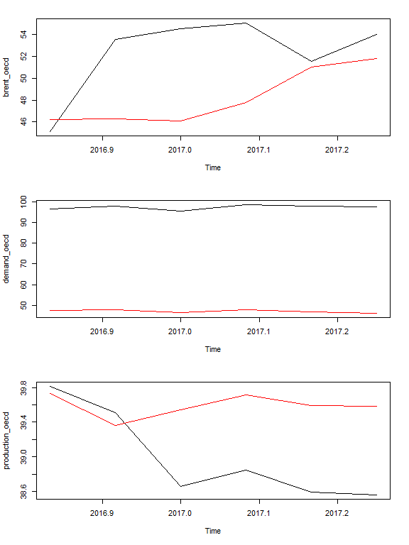

```r
plot(production_oecd, plot.type=c("single"), col=1:2)
```

```r
par(mfrow=c(3,1))
plot(brent_oecd_log, plot.type=c("single"), col=1:2)
plot(demand_oecd_log, plot.type=c("single"), col=1:2)
```

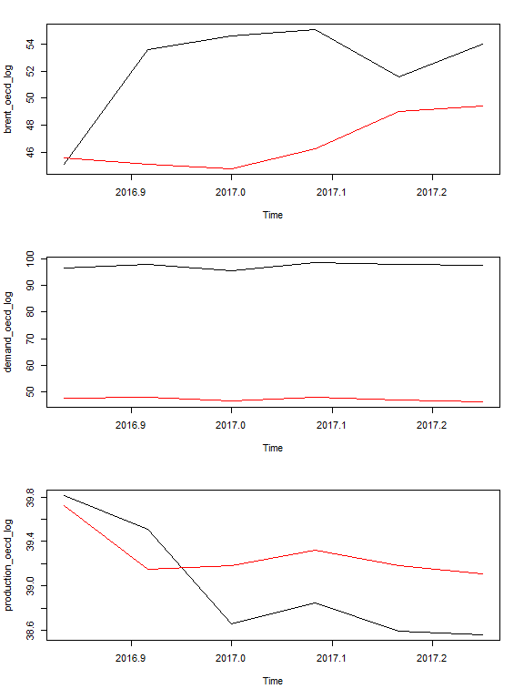

```r
plot(production_oecd_log, plot.type=c("single"), col=1:2)
```